# CMP713 Data Mining

### TASK 3

Draw a boxplot for each feature of the data (except the target column at the end).

- Discuss the shapes of the plots
- Do you notice anything weird?
- Why do you have so many “outliers”? Discuss potential reasons.
- What can be learned about the data from these plots?

#### Answer

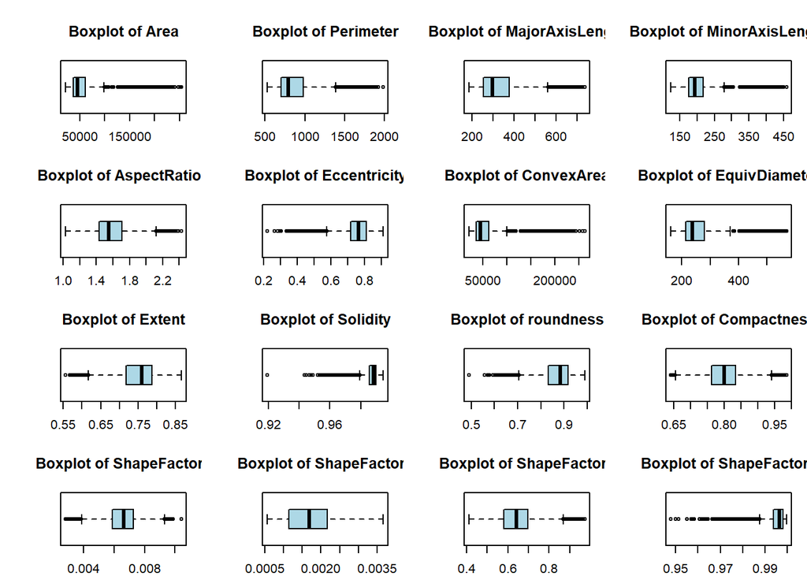

```r
par(mfrow = c(4,4), mar = c(2, 4, 4, 1))

for (colname in selected_columns) {
  boxplot(beans[[colname]],
          main = paste("Boxplot of", colname),
          col = "lightblue",
          horizontal = TRUE)
}
```

```r
par(mfrow = c(1,1))
```

### TASK 4

Draw a boxplot of each feature again, but this time facet the data with respect to the dry bean classes in the target feature (Class).

- Explain your findings after this new insight into the data
- Try to use the plots from Task 2, Task 3 and Task 4 together to come up with some understanding of the data.
- What are some useful features to classify dry beans and what are the potentially unnecessary features?

#### Answer

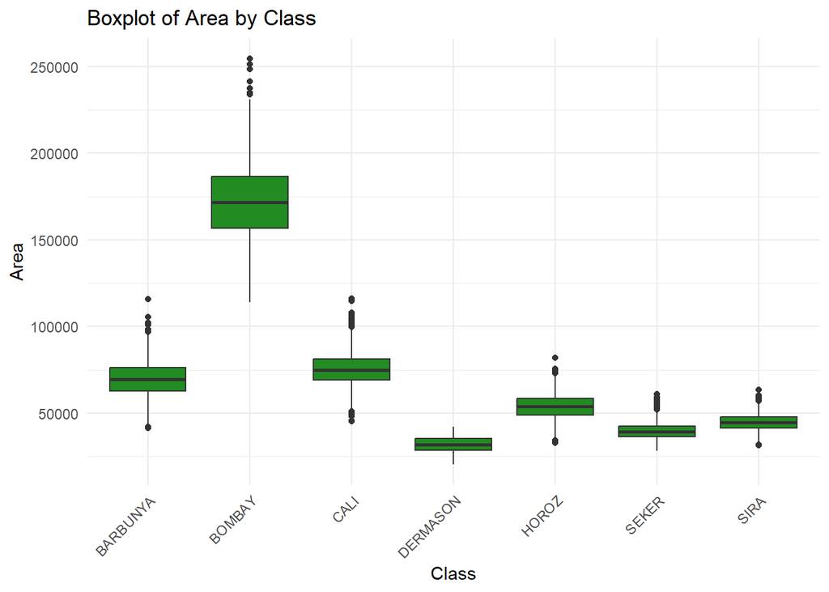

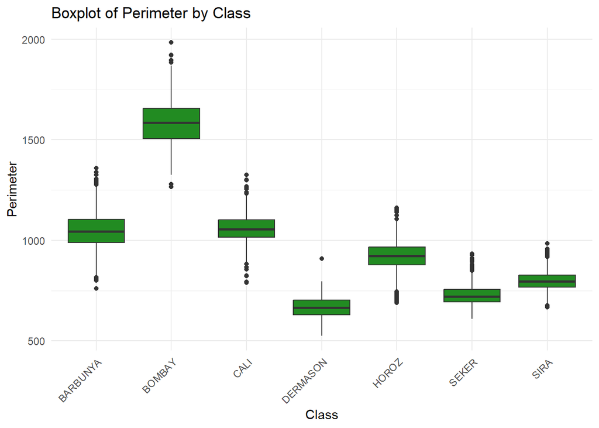

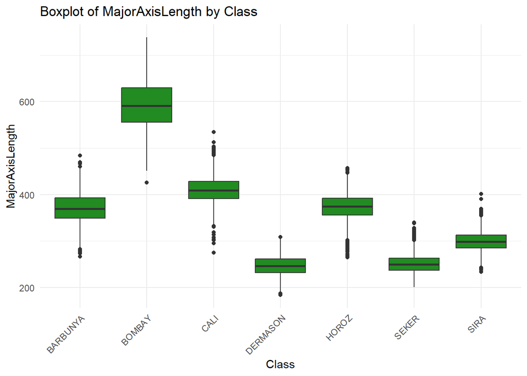

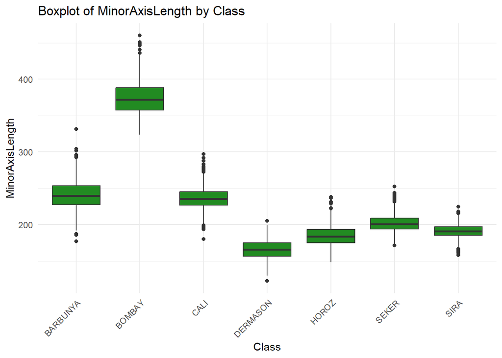

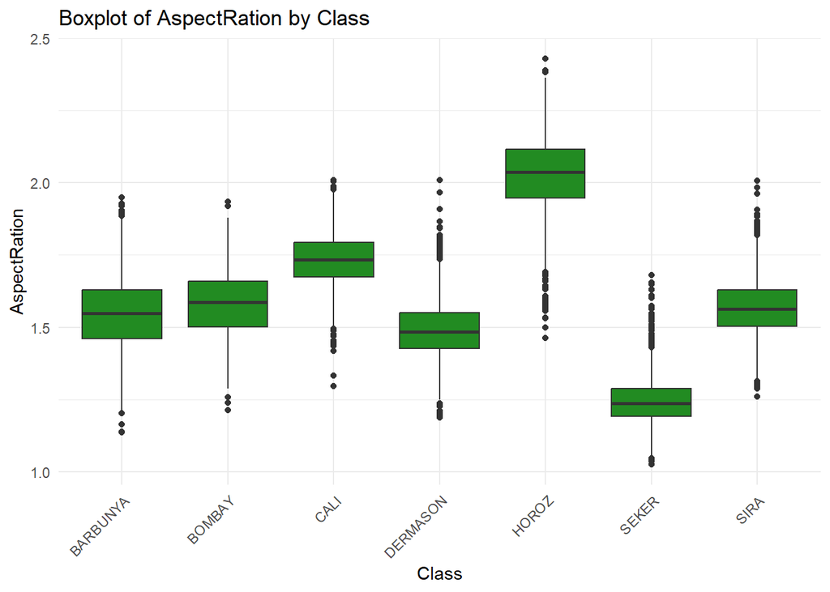

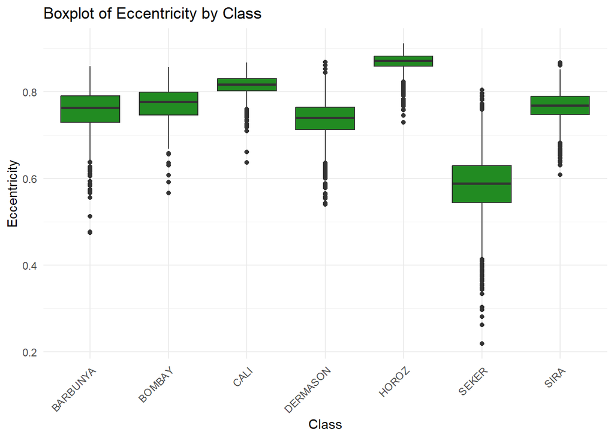

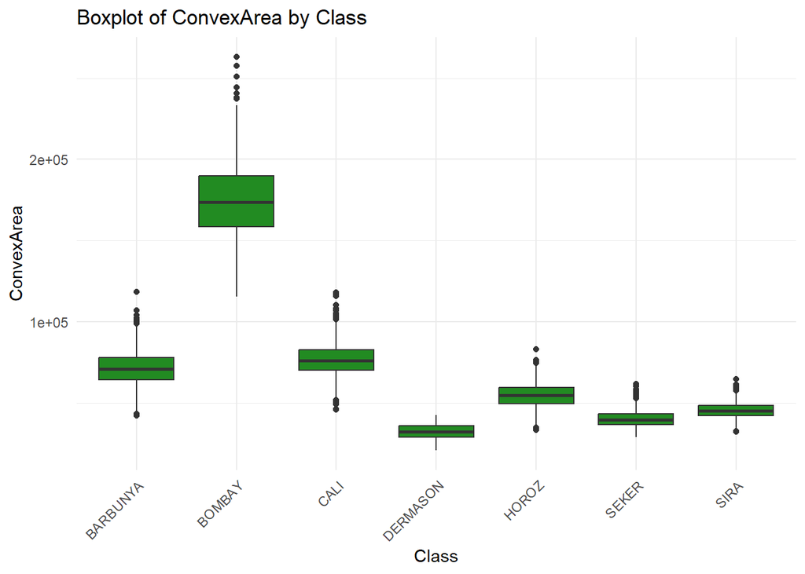

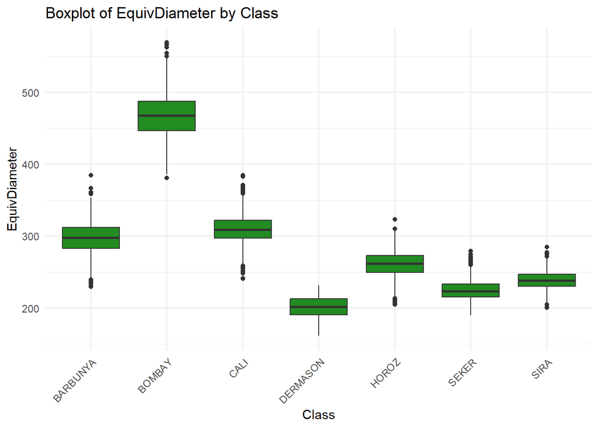

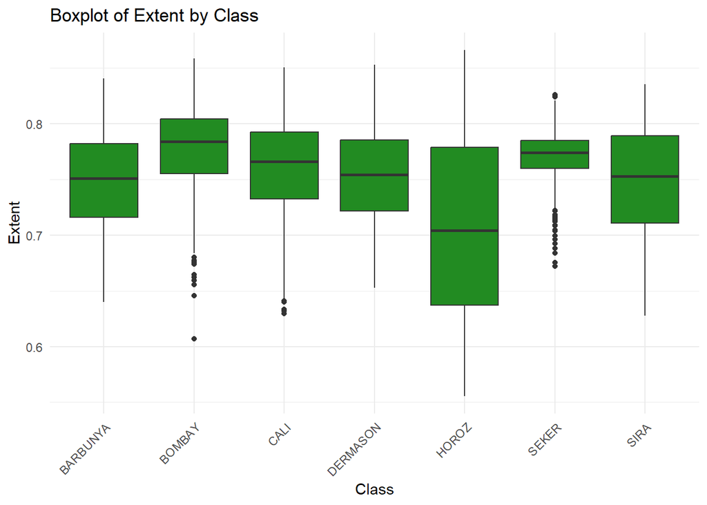

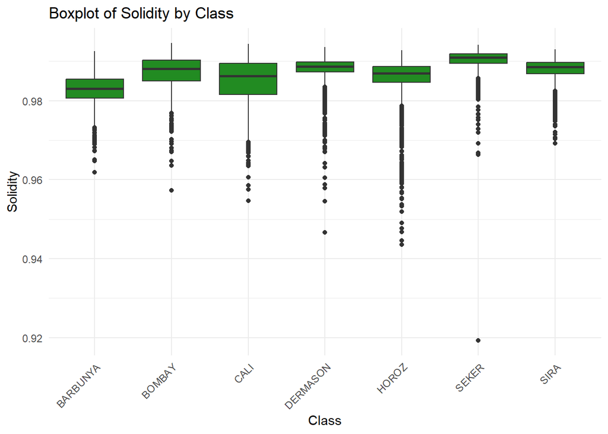

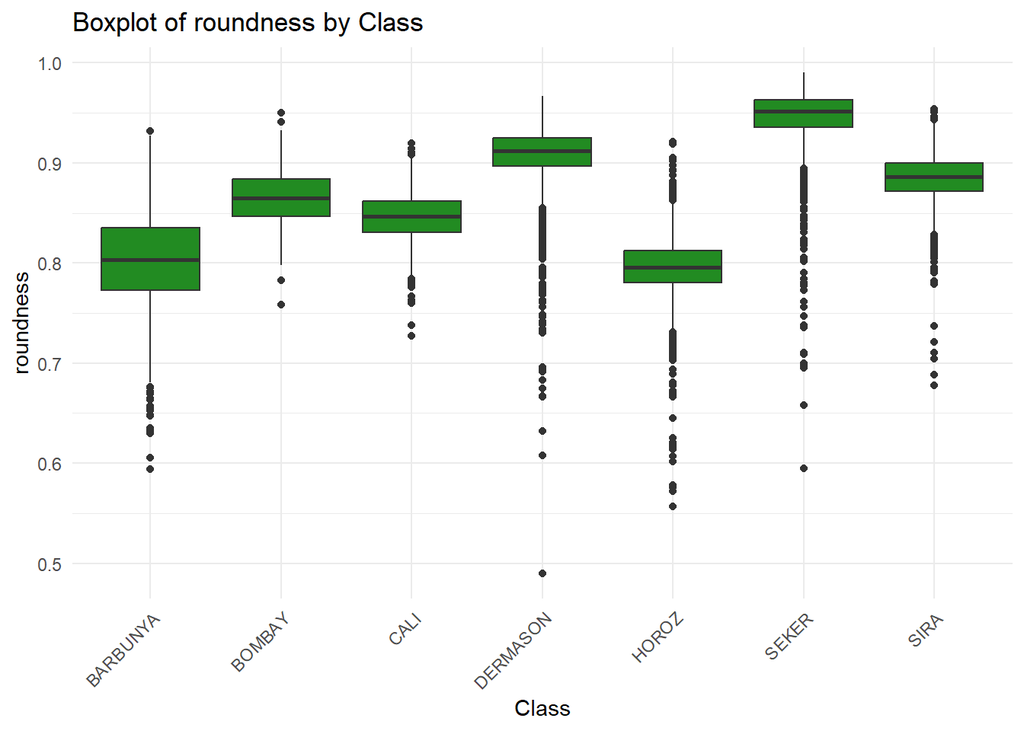

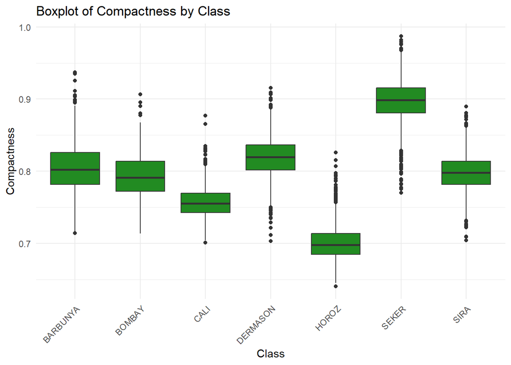

[4 more figures not shown]

```r
for (colname in selected_columns) {
  p <- ggplot(beans, aes_string(x = "Class", y = colname)) +
    geom_boxplot(fill = "forestgreen") +
    labs(x = "Class", y = colname, title = paste("Boxplot of", colname, "by Class")) +
    theme_minimal() +
    theme(axis.text.x = element_text(angle = 45, hjust = 1))

  print(p)
}
```